# Downloading and preparing temperature for ISIMIP 3a Baltic mizer

Author

Max Lindmark, following Phoebe.Woodworth-Jefcoats@noaa.gov

Published

2024-02-16

This document describes the workflow for preparing the ISIMIP 3a temperature data for use in the Baltic mizer model. It includes downloading and prepping the temperature data.

Temperature in mizer is to be calculated as follows:

Create a bias-corrected temperature time series as follows:

(Obsclim time series - Control data average value) + WOA average value

## Data Access

The first step was accessing the ISIMIP data. I could use the access_levante.text, but I couldn’t figure out how to do it manually. I needed to do it because then I can filter by extent (Lat: 53–61, Lon: 12–32). This is necessary otherwise I get memory overload. Possibly I can use the download from the terminal if I use the `hyperfilter` function in the tidync package as I do in the plankton script — I haven’t tested.

I also used World Ocean Atlas (WOA) data as a baseline temperature. I accessed the data from the [link](https://www.ncei.noaa.gov/thredds-ocean/catalog/ncei/woa/temperature/decav/1.00/catalog.html?dataset=ncei/woa/temperature/decav/1.00/woa18_decav_t00_01.nc) in draft protocoll (using the second download option, HTTPServer: /thredds-ocean/fileServer/ncei/woa/temperature/decav/1.00/woa18_decav_t00_01.nc).

## Data downloading and wrangling

```r
library(tidyverse); theme_set(theme_light())
library(tidylog)
library(ncdf4)
library(lubridate)
library(raster)
home <- here::here()
```

According to the draft protocol, the temperature to put into mizer is this: (Obsclim time series - Control data average value ) + WOA average value.

First do the WOA average. Here’s what I downloaded from the link in the draft Protocol

### Calculate the WOA average

```r
# https://towardsdatascience.com/how-to-crack-open-netcdf-files-in-r-and-extract-data-as-time-series-24107b70dcd

nc_dat <- nc_open(paste0(home, "/baltic/FishMIP/Temperature/DataFiles/woa18_decav_t00_01.nc"))

print(nc_dat)
```

```
File /Users/maxlindmark/Dropbox/Max work/R/mizer-rewiring-baltic/baltic/FishMIP/Temperature/DataFiles/woa18_decav_t00_01.nc (NC_FORMAT_NETCDF4_CLASSIC):

     12 variables (excluding dimension variables):
        int crs[]   (Contiguous storage)
            grid_mapping_name: latitude_longitude
            epsg_code: EPSG:4326
            longitude_of_prime_meridian: 0
            semi_major_axis: 6378137
            inverse_flattening: 298.257232666016
        float lat_bnds[nbounds,lat]   (Contiguous storage)
            comment: latitude bounds
        float lon_bnds[nbounds,lon]   (Contiguous storage)
            comment: longitude bounds
        float depth_bnds[nbounds,depth]   (Contiguous storage)
            comment: depth bounds
        float climatology_bounds[nbounds,time]   (Contiguous storage)
            comment: This variable defines the bounds of the climatological time period for each time
        float t_an[lon,lat,depth,time]   (Contiguous storage)
            standard_name: sea_water_temperature
            long_name: Objectively analyzed mean fields for sea_water_temperature at standard depth levels.
            coordinates: time lat lon depth
            cell_methods: area: mean depth: mean time: mean within years time: mean over years
            grid_mapping: crs
            units: degrees_celsius
            _FillValue: 9.96920996838687e+36
        float t_mn[lon,lat,depth,time]   (Contiguous storage)
            standard_name: sea_water_temperature
            long_name: Average of all unflagged interpolated values at each standard depth level for sea_water_temperature in each grid-square which contain at least one measurement.
            coordinates: time lat lon depth
            cell_methods: area: mean depth: mean time: mean within years time: mean over years
            grid_mapping: crs
            units: degrees_celsius
            _FillValue: 9.96920996838687e+36
        int t_dd[lon,lat,depth,time]   (Contiguous storage)
            standard_name: sea_water_temperature number_of_observations
            long_name: The number of observations of sea_water_temperature in each grid-square at each standard depth level.
            coordinates: time lat lon depth
            cell_methods: area: sum depth: point time: sum
            grid_mapping: crs
            units: 1
```

[output cut: 94 more lines]

```
        keywords_vocabulary: ISO 19115
        standard_name_vocabulary: CF Standard Name Table v49
        contributor_name: Ocean Climate Laboratory
        contributor_role: Calculation of climatologies
        cdm_data_type: Grid
        publisher_name: National Centers for Environmental Information (NCEI)
        publisher_institution: National Centers for Environmental Information
        publisher_type: institution
        publisher_url: http://www.ncei.noaa.gov/
        publisher_email: NCEI.info@noaa.gov
        nodc_template_version: NODC_NetCDF_Grid_Template_v2.0
        license: These data are openly available to the public. Please acknowledge the use of these data with the text given in the acknowledgment attribute.
        metadata_link: https://www.nodc.noaa.gov/OC5/woa18/
        date_created: 2019-07-28
        date_modified: 2019-07-28
```

```r
attributes(nc_dat$var)
```

```
$names
 [1] "crs"                "lat_bnds"           "lon_bnds"
 [4] "depth_bnds"         "climatology_bounds" "t_an"
 [7] "t_mn"               "t_dd"               "t_sd"
[10] "t_se"               "t_oa"               "t_gp"
```

```r
attributes(nc_dat$dim)
```

```
$names
[1] "nbounds" "lat"     "lon"     "depth"   "time"
```

```r
lat <- ncvar_get(nc_dat, "lat")
lon <- ncvar_get(nc_dat, "lon")
depth <- ncvar_get(nc_dat, "depth")

# Get the time variable. Remember: our metadata said our time units are in months since 1955-01-01 00:00:00, so you will not see a recognizable date and time format. We will take care of this later
time <- ncvar_get(nc_dat, "time")
time
```

```
[1] 4326
```

```r
# It's only length one? So this is the relevant time average, I just need to do filter and average spatially?
tunits <- ncatt_get(nc_dat, "time", "units") # Check units
tunits
```

```
$hasatt
[1] TRUE

$value
[1] "months since 1955-01-01 00:00:00"
```

```r
months_since_1955 <- time
date_ref = as.Date("1955-01-01")
date_ref %m+% months(months_since_1955)
```

```
[1] "2315-07-01"
```

```r
# Get the variable in "matrix slices"
temp_array <- ncvar_get(nc_dat, "t_an")

dim(temp_array)
```

```
[1] 360 180 102
```

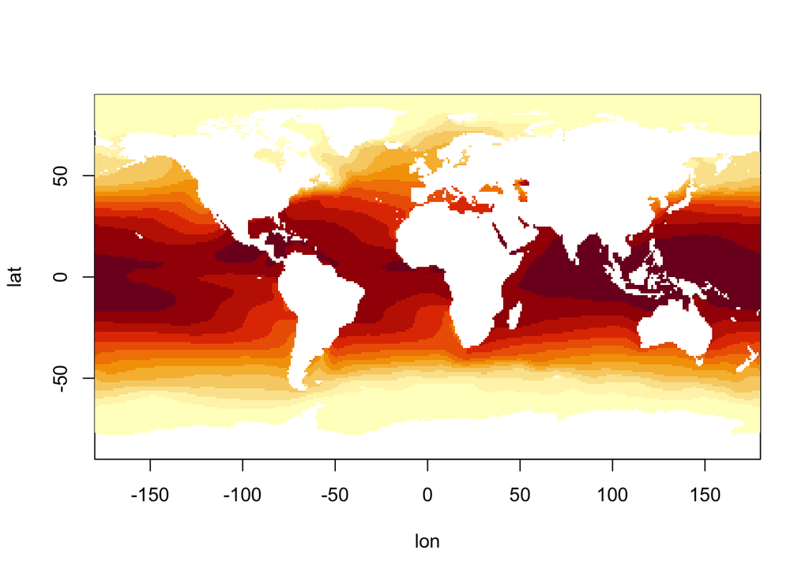

```r
temp_slice <- temp_array[ , , 1]

image(lon, lat, temp_slice)
```

```r
lonlattime <- as.matrix(expand.grid(lon, lat, depth)) # This might take several seconds

# Reshape whole temp_array
temp_long <- as.vector(temp_array)
length(temp_long)
```

```
[1] 6609600
```

```r
# Create data.frame
temp <- data.frame(cbind(lonlattime, temp_long))

colnames(temp) <- c("lon", "lat", "depth", "temperature")

head(temp)
```

```
     lon   lat depth temperature
1 -179.5 -89.5     0          NA
2 -178.5 -89.5     0          NA
3 -177.5 -89.5     0          NA
4 -176.5 -89.5     0          NA
5 -175.5 -89.5     0          NA
6 -174.5 -89.5     0          NA
```

```r
# hist(temp$depth)
# hist(temp$temperature)

# Trim the dataframe a little bit
temp <- temp %>% filter(lon > 5 & lon < 30 & lat > 50 & lat < 60)
```

```
filter: removed 6,584,100 rows (>99%), 25,500 rows remaining
```

```r
# Now add ICES statistical subdivision information and filter
# Add ICES areas
# https://stackoverflow.com/questions/34272309/extract-shapefile-value-to-point-with-r
# https://gis.ices.dk/sf/
shape <- shapefile(paste0(home, "/baltic/FishMIP/ICES-StatRec-mapto-ICES-Areas/StatRec_map_Areas_Full_20170124.shp"))
head(shape)
```

```
  OBJECTID ID ICESNAME SOUTH WEST NORTH EAST AREA_KM2 stat_x stat_y Area_27
1        1 47     47A0  59.0  -44  59.5  -43     3178  -43.5  59.25  14.b.2
2        2 48     48A0  59.5  -44  60.0  -43     3132  -43.5  59.75  14.b.2
3        3 49     49A0  60.0  -44  60.5  -43     3085  -43.5  60.25  14.b.2
4        4 50     50A0  60.5  -44  61.0  -43     3038  -43.5  60.75  14.b.2
5        5 51     51A0  61.0  -44  61.5  -43     2991  -43.5  61.25  14.b.2
6        6 52     52A0  61.5  -44  62.0  -43     2944  -43.5  61.75  14.b.2
          Perc      MaxPer RNDMaxPer AreasList Shape_Leng Shape_Area
1 100.00000000 100.0000000       100    14.b.2          3        0.5
2  84.12674145  84.1267414        84    14.b.2          3        0.5
3  24.99803694  24.9980369        25    14.b.2          3        0.5
4  11.97744244  11.9774424        12    14.b.2          3        0.5
5   3.89717625   3.8971762         4    14.b.2          3        0.5
6   0.28578428   0.2857843         0    14.b.2          3        0.5
```

```r
pts <- SpatialPoints(cbind(temp$lon, temp$lat),
                     proj4string = CRS(proj4string(shape)))

temp$subdiv <- over(pts, shape)$Area_27

# Rename subdivisions to the more common names and do some more filtering (by sub div and area)
sort(unique(temp$subdiv))
```

```
 [1] "3.a.20"   "3.a.21"   "3.b.23"   "3.c.22"   "3.d.24"   "3.d.25"
 [7] "3.d.26"   "3.d.27"   "3.d.28.1" "3.d.28.2" "3.d.29"   "3.d.32"
[13] "4.a"      "4.b"      "4.c"
```

```r
temp <- temp |>
  mutate(sub_div = factor(subdiv),
         sub_div = fct_recode(subdiv,
                              "25" = "3.d.25",
                              "26" = "3.d.26",
                              "27" = "3.d.27",
                              "28" = "3.d.28.1",
                              "28" = "3.d.28.2",
                              "29" = "3.d.29",
                              "32" = "3.d.32"),
         sub_div = as.character(sub_div)) %>%
  filter(sub_div %in% c(25, 26, 27, 28, 29, 32))
```

```
mutate: new variable 'sub_div' (character) with 15 unique values and 58% NA
```

```
filter: removed 20,400 rows (80%), 5,100 rows remaining
```

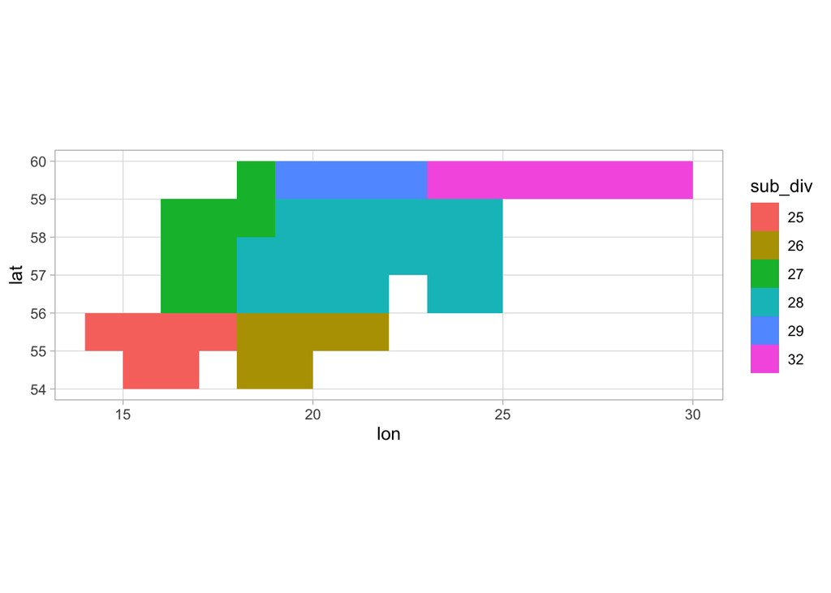

```r
ggplot(temp, aes(lon, lat, fill = sub_div)) +
  geom_raster() +
  coord_sf()
```

```r
# Now filter only bottom temp
sbt <- temp %>%
  drop_na(temperature) %>%
  mutate(loc = paste(lon, lat)) %>%
  group_by(loc) %>%
  filter(depth == max(depth)) %>%
  ungroup()
```

```
drop_na: removed 4,723 rows (93%), 377 rows remaining
```

```
mutate: new variable 'loc' (character) with 22 unique values and 0% NA
```

```
group_by: one grouping variable (loc)
```

```
filter (grouped): removed 355 rows (94%), 22 rows remaining
```

```
ungroup: no grouping variables
```

```r
sbt
```

```
# A tibble: 22 × 7
     lon   lat depth temperature subdiv   sub_div loc
   <dbl> <dbl> <dbl>       <dbl> <chr>    <chr>   <chr>
 1  19.5  59.5    10        6.90 3.d.29   29      19.5 59.5
 2  17.5  55.5    40        4.79 3.d.25   25      17.5 55.5
 3  17.5  56.5    40        3.38 3.d.27   27      17.5 56.5
 4  15.5  54.5    45        5.18 3.d.25   25      15.5 54.5
 5  18.5  56.5    50        2.91 3.d.28.2 28      18.5 56.5
 6  20.5  55.5    55        3.51 3.d.26   26      20.5 55.5
 7  21.5  57.5    60        3.56 3.d.28.2 28      21.5 57.5
 8  20.5  56.5    70        3.28 3.d.28.2 28      20.5 56.5
 9  15.5  55.5    75        6.24 3.d.25   25      15.5 55.5
10  16.5  55.5    75        5.69 3.d.25   25      16.5 55.5
# ℹ 12 more rows
```

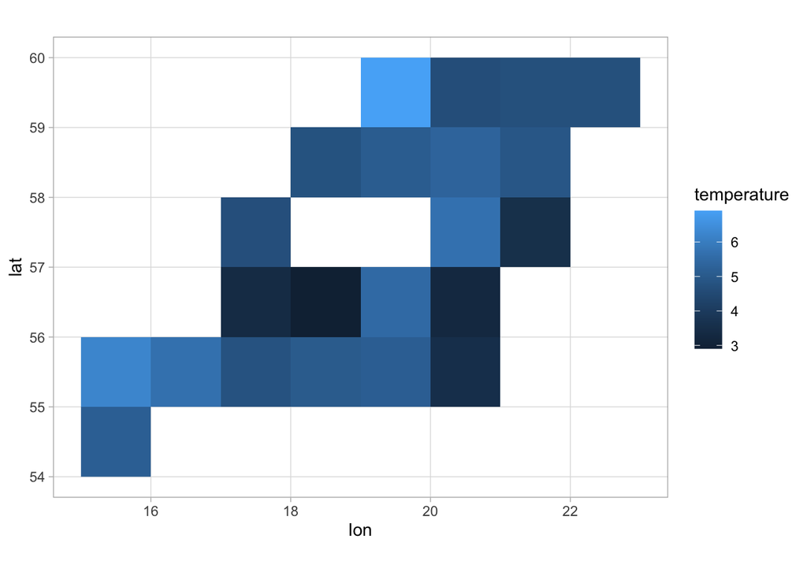

```r
ggplot(sbt, aes(lon, lat, fill = temperature)) +
  geom_raster() +
  coord_sf()
```

```r
# Calculate the mean
woa_avg_temp <- sbt %>% summarise(mean_sbt = mean(temperature))
```

```
summarise: now one row and one column, ungrouped
```

Control clim, from this link: https://data.isimip.org/search/tree/ISIMIP3a/InputData/climate/ocean/gfdl-mom6-cobalt2/ctrlclim/thetao/

```r
# Read the nc file
# https://stackoverflow.com/questions/76624626/extracting-data-from-netcdf-file-in-r

nc_ctrl <- nc_open(paste0(home,
                         "/baltic/FishMIP/Temperature/DataFiles/ctrl_clim/gfdl-mom6-cobalt2_ctrlclim_thetao_15arcmin_lat53.0to61.0lon12.0to32.0_monthly_1961_2010.nc"))
print(nc_ctrl)
```

```
File /Users/maxlindmark/Dropbox/Max work/R/mizer-rewiring-baltic/baltic/FishMIP/Temperature/DataFiles/ctrl_clim/gfdl-mom6-cobalt2_ctrlclim_thetao_15arcmin_lat53.0to61.0lon12.0to32.0_monthly_1961_2010.nc (NC_FORMAT_NETCDF4_CLASSIC):

     1 variables (excluding dimension variables):
        float thetao[lon,lat,lev,time]   (Chunking: [80,32,1,1])  (Compression: shuffle,level 1)
            standard_name: sea_water_potential_temperature
            long_name: Sea Water Potential Temperature
            units: degC
            _FillValue: 1.00000002004088e+20
            missing_value: 1.00000002004088e+20
            GFDL_variable: thetao

     4 dimensions:
        lat  Size:32
            standard_name: latitude
            long_name: latitude
            units: degrees_north
            axis: Y
        lev  Size:35
            long_name: Depth at cell center
            units: meters
            positive: down
            axis: Z
            cartesian_axis: Z
            edges: z_i
        lon  Size:80
            standard_name: longitude
            long_name: longitude
            units: degrees_east
            axis: X
        time  Size:600   *** is unlimited ***
            standard_name: time
            long_name: time
            units: months since 1901-1-1 00:00:00
            calendar: 360_day
            axis: T

    10 global attributes:
        CDI: Climate Data Interface version 1.9.8 (https://mpimet.mpg.de/cdi)
        Conventions: CF-1.6
        filename: 19610101.ocean_month_z.nc
        title: OM4p25_LM3TAN_jra_from1959_init234yrs_1950rivernut_O1756_new
        associated_files: areacello: 19610101.ocean_static.nc
        grid_type: regular
        grid_tile: N/A
        NCO: "4.5.4"
        cdo_openmp_thread_number: 4
        isimip_id: 496f4828-ee8e-4afe-a94a-0bb931557a9f
```

```r
attributes(nc_ctrl$var)
```

```
$names
[1] "thetao"
```

```r
attributes(nc_ctrl$dim)
```

```
$names
[1] "lat"  "lev"  "lon"  "time"
```

```r
lat <- ncvar_get(nc_ctrl, "lat")
lon <- ncvar_get(nc_ctrl, "lon")
depth <- ncvar_get(nc_ctrl, "lev")

# Get the time variable.
time <- ncvar_get(nc_ctrl, "time")
head(time)
```

```
[1] 720 721 722 723 724 725
```

```r
# Check time unit
ncatt_get(nc_ctrl, "time", "units")
```

```
$hasatt
[1] TRUE

$value
[1] "months since 1901-1-1 00:00:00"
```

```r
# Extract time in date format
months_since_1901 <- time
date_ref = as.Date("1901-01-01")
dates <- date_ref %m+% months(months_since_1901) %>% as.character()
head(dates)
```

```
[1] "1961-01-01" "1961-02-01" "1961-03-01" "1961-04-01" "1961-05-01"
[6] "1961-06-01"
```

```r
# Get the variable in "matrix slices"
ctrl_array <- ncvar_get(nc_ctrl, "thetao")
dim(ctrl_array)
```

```
[1]  80  32  35 600
```

```r
# Expand grid lon lat and depth, to which be cbind the actual values
ctrl_grid <- as.matrix(expand.grid(lon, lat, depth, dates)) # This might take several seconds

# Now add in the temperatures
ctrl_df <- as.vector(ctrl_array)

ctrl_df <- data.frame(cbind(ctrl_grid, ctrl_df))

colnames(ctrl_df) <- c("lon", "lat", "depth", "date", "ctrl_temp")

# Filter NA temperatures and select the deepest depth
ctrl_df <- ctrl_df %>%
  drop_na(ctrl_temp) %>%
  group_by(lon, lat) %>%
  filter(depth == max(depth)) %>% # TODO: I wonder if this is the correct way to get the bottom depth
  ungroup() %>%
  mutate(lon = as.numeric(lon),
         lat = as.numeric(lat),
         depth = as.numeric(depth),
         date = as.Date(date),
         ctrl_temp = as.numeric(ctrl_temp)) %>%
  mutate(year = year(date))
```

```
drop_na: removed 52,264,200 rows (97%), 1,495,800 rows remaining
```

```
group_by: 2 grouping variables (lon, lat)
```

```
filter (grouped): removed 1,146,000 rows (77%), 349,800 rows remaining
```

```
ungroup: no grouping variables
```

```
mutate: converted 'lon' from character to double (0 new NA)
```

```
        converted 'lat' from character to double (0 new NA)
```

```
        converted 'depth' from character to double (0 new NA)
```

```
        converted 'date' from character to Date (0 new NA)
```

```
        converted 'ctrl_temp' from character to double (0 new NA)
```

```
mutate: new variable 'year' (double) with 50 unique values and 0% NA
```

```r
# Add in ICES areas so that we can filter the domain of the mizer model
shape <- shapefile(paste0(home, "/baltic/FishMIP/ICES-StatRec-mapto-ICES-Areas/StatRec_map_Areas_Full_20170124.shp"))

pts <- SpatialPoints(cbind(ctrl_df$lon, ctrl_df$lat),
                     proj4string = CRS(proj4string(shape)))

ctrl_df$subdiv <- over(pts, shape)$Area_27

# Rename subdivisions to the more common names and do some more filtering (by sub div and area)
sort(unique(temp$subdiv))
```

```
[1] "3.d.25"   "3.d.26"   "3.d.27"   "3.d.28.1" "3.d.28.2" "3.d.29"   "3.d.32"
```

```r
ctrl_df <- ctrl_df |>
  mutate(sub_div = factor(subdiv),
         sub_div = fct_recode(subdiv,
                              "25" = "3.d.25",
                              "26" = "3.d.26",
                              "27" = "3.d.27",
                              "28" = "3.d.28.1",
                              "28" = "3.d.28.2",
                              "29" = "3.d.29",
                              "32" = "3.d.32"),
         sub_div = as.character(sub_div)) %>%
  filter(sub_div %in% c(25, 26, 27, 28, 29, 32))
```

```
mutate: new variable 'sub_div' (character) with 10 unique values and 0% NA
```

```
filter: removed 46,200 rows (13%), 303,600 rows remaining
```

```
filter: removed 303,094 rows (>99%), 506 rows remaining
```

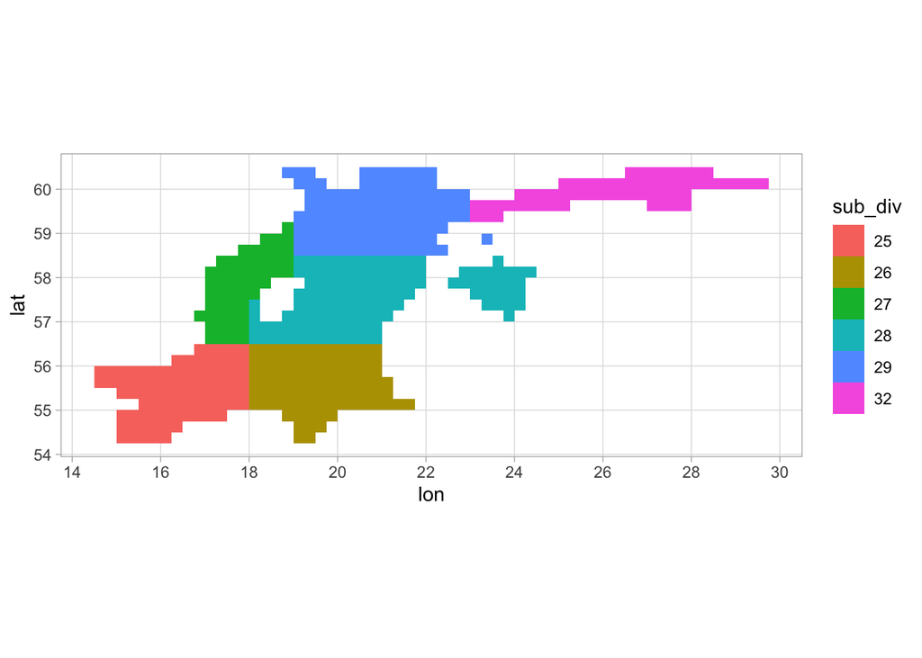

```r
# Plot sub division
ctrl_df %>%
  filter(date == "1961-01-01") %>% # Filter specific time
  ggplot(aes(lon, lat, fill = sub_div)) +
  geom_raster() +
  coord_sf()
```

```
filter: removed 303,094 rows (>99%), 506 rows remaining
```

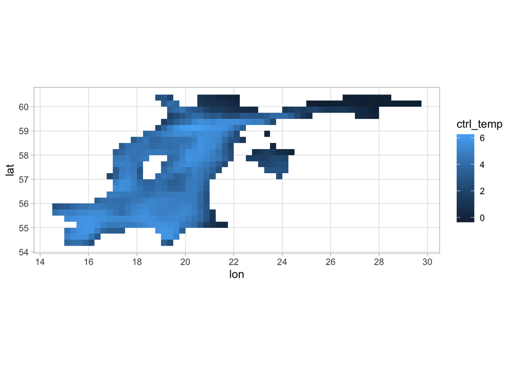

```r
# Test plotting temperature for the first time step
ctrl_df %>%
  filter(date == "1961-01-01") %>% # Filter specific time
  ggplot(aes(lon, lat, fill = ctrl_temp)) +
  geom_raster() +
  coord_sf()
```

```
filter: removed 303,094 rows (>99%), 506 rows remaining
```

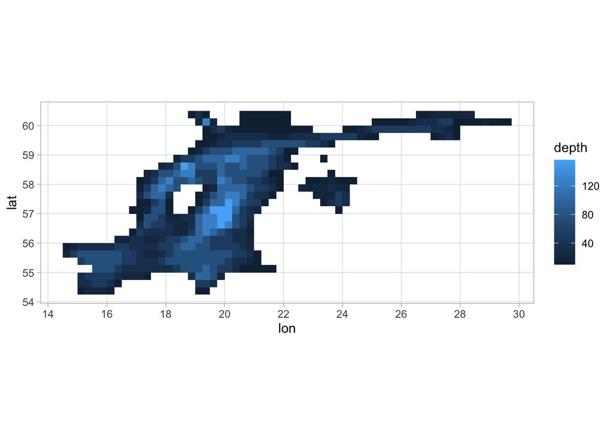

```r
# Depth
ctrl_df %>%
  filter(date == "1961-01-01") %>% # Filter specific time
  ggplot(aes(lon, lat, fill = depth)) +
  geom_raster() +
  coord_sf()
```

```
summarise: now 600 rows and 2 columns, ungrouped
```

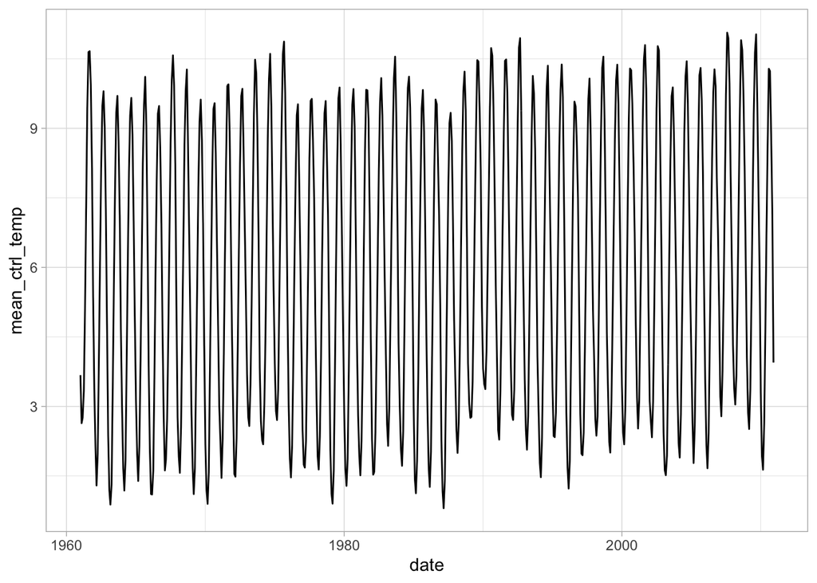

```r
# TODO: Average by date (year + month) and plot... or do I change my dt to 1/12 and take the monthly averages?
ctrl_df %>%
  summarise(mean_ctrl_temp = mean(ctrl_temp), .by = date) %>%
  ggplot(aes(date, mean_ctrl_temp)) +
  geom_line()
```

```r
ctrl_annual <- ctrl_df %>%
  summarise(mean_ctrl_temp = mean(ctrl_temp), .by = date)
```

```
summarise: now 600 rows and 2 columns, ungrouped
```

```r
nc_obs <- nc_open(paste0(home,
                         "/baltic/FishMIP/Temperature/DataFiles/obs_clim/gfdl-mom6-cobalt2_obsclim_thetao_15arcmin_lat53.0to61.0lon12.0to32.0_monthly_1961_2010.nc"))
print(nc_obs)
```

```
File /Users/maxlindmark/Dropbox/Max work/R/mizer-rewiring-baltic/baltic/FishMIP/Temperature/DataFiles/obs_clim/gfdl-mom6-cobalt2_obsclim_thetao_15arcmin_lat53.0to61.0lon12.0to32.0_monthly_1961_2010.nc (NC_FORMAT_NETCDF4_CLASSIC):

     1 variables (excluding dimension variables):
        float thetao[lon,lat,lev,time]   (Chunking: [80,32,1,1])  (Compression: level 5)
            standard_name: sea_water_potential_temperature
            long_name: Sea Water Potential Temperature
            units: degC
            _FillValue: 1.00000002004088e+20
            missing_value: 1.00000002004088e+20
            GFDL_variable: thetao

     4 dimensions:
        lat  Size:32
            standard_name: latitude
            long_name: latitude
            units: degrees_north
            axis: Y
        lev  Size:35
            long_name: Depth at cell center
            units: meters
            positive: down
            axis: Z
            cartesian_axis: Z
            edges: z_i
        lon  Size:80
            standard_name: longitude
            long_name: longitude
            units: degrees_east
            axis: X
        time  Size:600   *** is unlimited ***
            standard_name: time
            long_name: time
            units: months since 1901-1-1 00:00:00
            calendar: 360_day
            axis: T

    10 global attributes:
        CDI: Climate Data Interface version 1.9.8 (https://mpimet.mpg.de/cdi)
        Conventions: CF-1.6
        filename: 19610101.ocean_month_z.nc
        title: OM4p25_LM3TAN_jra_from1959_init234yrs_dynrivernut_O1756_new
        associated_files: areacello: 19610101.ocean_static.nc
        grid_type: regular
        grid_tile: N/A
        NCO: "4.5.4"
        cdo_openmp_thread_number: 4
        isimip_id: 74b33222-d091-4c51-8beb-5ce2e7cd24be
```

```r
attributes(nc_obs$var)
```

```
$names
[1] "thetao"
```

```r
attributes(nc_obs$dim)
```

```
$names
[1] "lat"  "lev"  "lon"  "time"
```

```r
lat <- ncvar_get(nc_obs, "lat")
lon <- ncvar_get(nc_obs, "lon")
depth <- ncvar_get(nc_obs, "lev")

# Get the time variable.
time <- ncvar_get(nc_obs, "time")
head(time)
```

```
[1] 720 721 722 723 724 725
```

```r
# Check time unit
ncatt_get(nc_obs, "time", "units")
```

```
$hasatt
[1] TRUE

$value
[1] "months since 1901-1-1 00:00:00"
```

```r
# Extract time in date format
months_since_1901 <- time
date_ref = as.Date("1901-01-01")
dates <- date_ref %m+% months(months_since_1901) %>% as.character()
head(dates)
```

```
[1] "1961-01-01" "1961-02-01" "1961-03-01" "1961-04-01" "1961-05-01"
[6] "1961-06-01"
```

```r
# Get the variable in "matrix slices"
obs_array <- ncvar_get(nc_obs, "thetao")
dim(obs_array)
```

```
[1]  80  32  35 600
```

```r
# Expand grid lon lat and depth, to which be cbind the actual values
obs_grid <- as.matrix(expand.grid(lon, lat, depth, dates)) # This might take several seconds

# Now add in the temperatures
obs_df <- as.vector(obs_array)

obs_df <- data.frame(cbind(obs_grid, obs_df))

colnames(obs_df) <- c("lon", "lat", "depth", "date", "obs_temp")

# Filter NA temperatures and select the deepest depth
obs_df <- obs_df %>%
  drop_na(obs_temp) %>%
  group_by(lon, lat) %>%
  filter(depth == max(depth)) %>% # TODO: I wonder if this is the correct way to get the bottom depth
  ungroup() %>%
  mutate(lon = as.numeric(lon),
         lat = as.numeric(lat),
         depth = as.numeric(depth),
         date = as.Date(date),
         obs_temp = as.numeric(obs_temp)) %>%
  mutate(year = year(date))
```

```
drop_na: removed 52,264,200 rows (97%), 1,495,800 rows remaining
```

```
group_by: 2 grouping variables (lon, lat)
```

```
filter (grouped): removed 1,146,000 rows (77%), 349,800 rows remaining
```

```
ungroup: no grouping variables
```

```
mutate: converted 'lon' from character to double (0 new NA)
```

```
        converted 'lat' from character to double (0 new NA)
```

```
        converted 'depth' from character to double (0 new NA)
```

```
        converted 'date' from character to Date (0 new NA)
```

```
        converted 'obs_temp' from character to double (0 new NA)
```

```
mutate: new variable 'year' (double) with 50 unique values and 0% NA
```

```r
# Add in ICES areas so that we can filter the domain of the mizer model
shape <- shapefile(paste0(home, "/baltic/FishMIP/ICES-StatRec-mapto-ICES-Areas/StatRec_map_Areas_Full_20170124.shp"))

pts <- SpatialPoints(cbind(obs_df$lon, obs_df$lat),
                     proj4string = CRS(proj4string(shape)))

obs_df$subdiv <- over(pts, shape)$Area_27

# Rename subdivisions to the more common names and do some more filtering (by sub div and area)
obs_df <- obs_df |>
  mutate(sub_div = factor(subdiv),
         sub_div = fct_recode(subdiv,
                              "25" = "3.d.25",
                              "26" = "3.d.26",
                              "27" = "3.d.27",
                              "28" = "3.d.28.1",
                              "28" = "3.d.28.2",
                              "29" = "3.d.29",
                              "32" = "3.d.32"),
         sub_div = as.character(sub_div)) %>%
  filter(sub_div %in% c(25, 26, 27, 28, 29, 32))
```

```
mutate: new variable 'sub_div' (character) with 10 unique values and 0% NA
```

```
filter: removed 46,200 rows (13%), 303,600 rows remaining
```

```
filter: removed 303,094 rows (>99%), 506 rows remaining
```

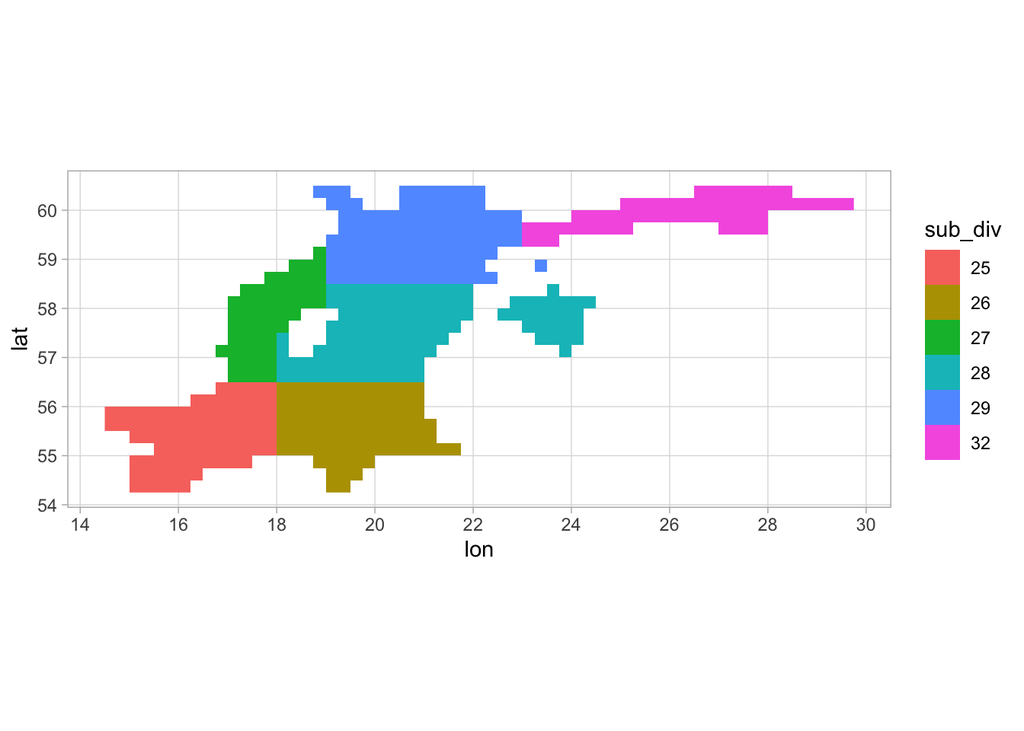

```r
# Plot sub division
obs_df %>%
  filter(date == "1961-01-01") %>% # Filter specific time
  ggplot(aes(lon, lat, fill = sub_div)) +
  geom_raster() +
  coord_sf()
```

```
filter: removed 303,094 rows (>99%), 506 rows remaining
```

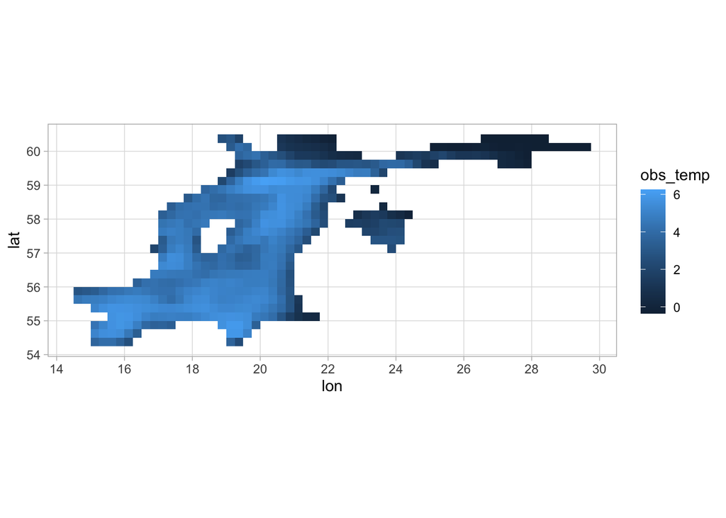

```r
# Test plotting temperature for the first time step
obs_df %>%
  filter(date == "1961-01-01") %>% # Filter specific time
  ggplot(aes(lon, lat, fill = obs_temp)) +
  geom_raster() +
  coord_sf()
```

```
filter: removed 303,094 rows (>99%), 506 rows remaining
```

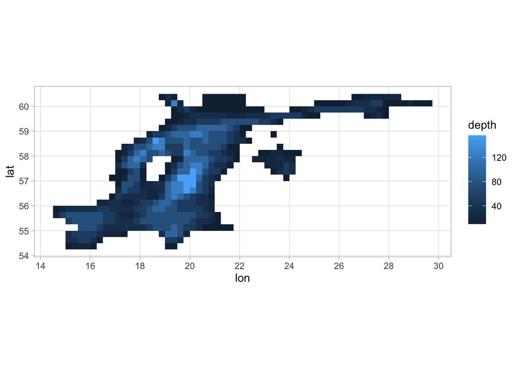

```r
# Depth
obs_df %>%
  filter(date == "1961-01-01") %>% # Filter specific time
  ggplot(aes(lon, lat, fill = depth)) +
  geom_raster() +
  coord_sf()
```

```
summarise: now 600 rows and 2 columns, ungrouped
```

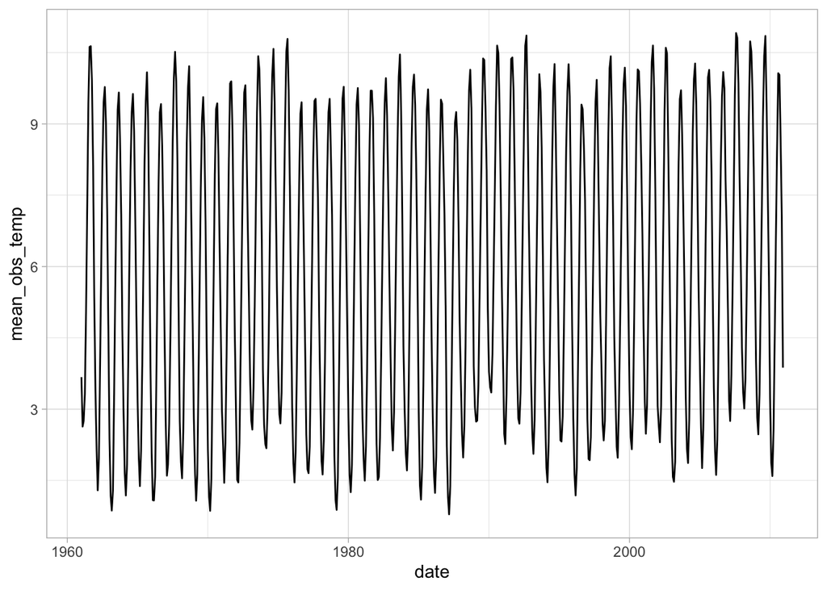

```r
# TODO: Average by year and plot... or do I change my dt to 1/12 and take the monthly averages?
obs_df %>%
  summarise(mean_obs_temp = mean(obs_temp), .by = date) %>%
  ggplot(aes(date, mean_obs_temp)) +
  geom_line()
```

```r
obs_annual <- obs_df %>%
  summarise(mean_obs_temp = mean(obs_temp), .by = date)
```

```
summarise: now 600 rows and 2 columns, ungrouped
```

Compare temperature series

```r
temps <- bind_rows(ctrl_annual %>% rename(temp = mean_ctrl_temp) %>% mutate(type = "ctrl"),
                   obs_annual %>% rename(temp = mean_obs_temp) %>% mutate(type = "obs"))
```

```
rename: renamed one variable (temp)
```

```
mutate: new variable 'type' (character) with one unique value and 0% NA
```

```
rename: renamed one variable (temp)
```

```
mutate: new variable 'type' (character) with one unique value and 0% NA
```

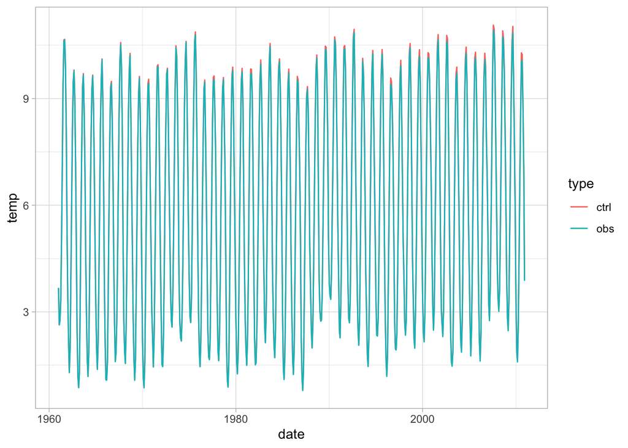

```r
ggplot(temps, aes(date, temp, color = type)) +
  geom_line()
```

Phoebe’s temperature bias correction involved*:

- Create a time series of average temperature (Jan 1961 - Dec 2010) across depth ranges and over the whole model area for the different ‘realms’ (different species’ vertical behavior) from the experiment data i.e. obsclim, 0.25 degree
- Create a time series of average temperature (Jan 1961 - Dec 1980) across depth ranges and over the whole model area for the different ‘realms’ from the control data i.e. ctrlclim, 0.25 degree. Calculate an average for each realm from the control time series. {note change on specifiers name, ctrclim is now named obsclim_1955-riverine-input}
- Using World Ocean Atlas climatology here, calculate the average temperature over various depth ranges and the whole model area. Create a bias-corrected temperature time series as follows:

(Obsclim time series - Control data average value ) + WOA average value

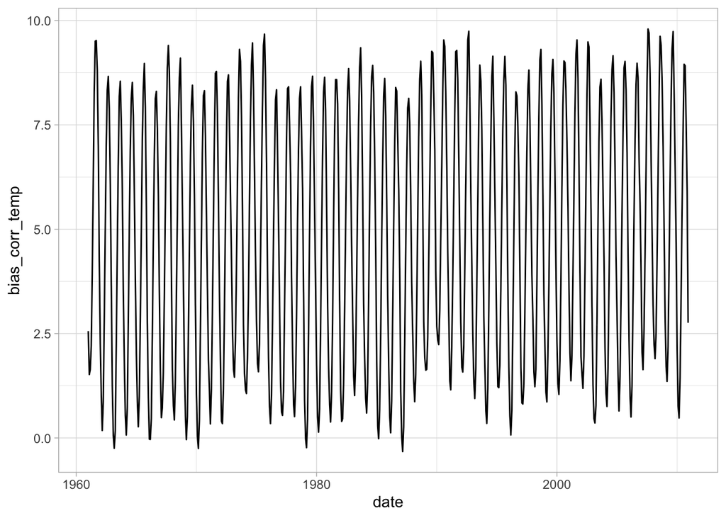

```r
# Temperature time series
temp_df <- tibble(bias_corr_temp = (obs_annual$mean_obs_temp - mean(ctrl_annual$mean_ctrl_temp)) + woa_avg_temp$mean_sbt,
                  date = obs_annual$date)

ggplot(temp_df, aes(date, bias_corr_temp)) +
  geom_line()
```

```r
# Add year-averaged temperature
temp_df <- temp_df %>%
  rename(temp = bias_corr_temp) %>%
  mutate(year = year(date)) %>%
  group_by(year) %>%
  mutate(temp_agg = mean(temp)) %>%
  ungroup()
```

```
rename: renamed one variable (temp)
```

```
mutate: new variable 'year' (double) with 50 unique values and 0% NA
```

```
group_by: one grouping variable (year)
```

```
mutate (grouped): new variable 'temp_agg' (double) with 50 unique values and 0% NA
```

```
ungroup: no grouping variables
```

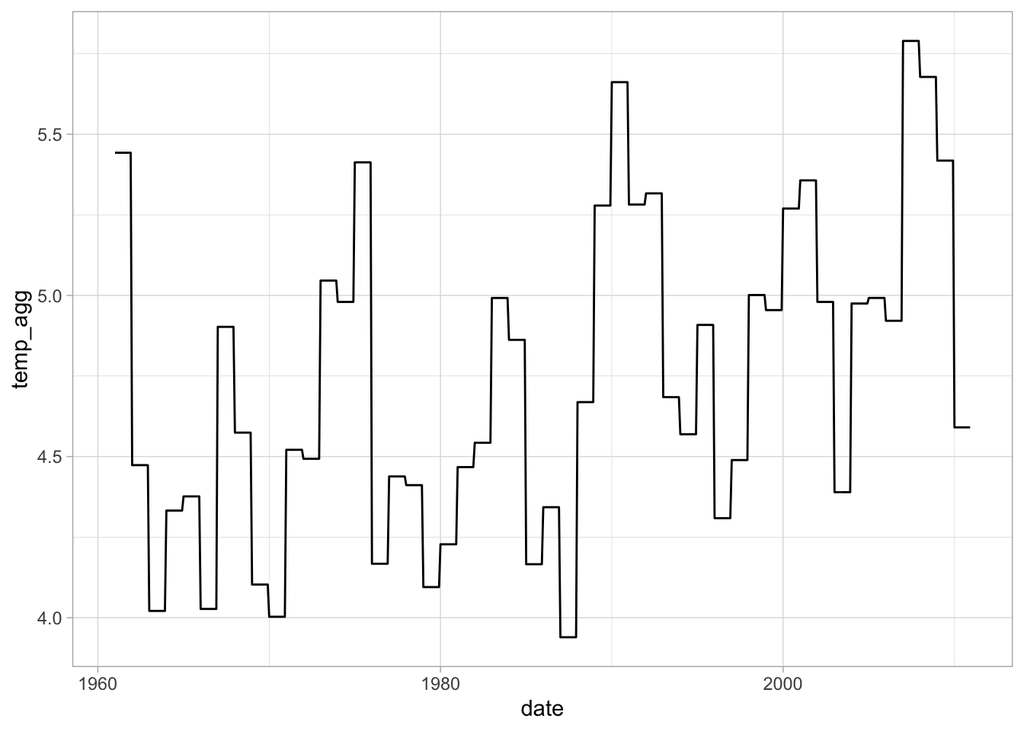

```r
ggplot(temp_df, aes(date, temp_agg)) +
  geom_line()
```

```
distinct: removed 550 rows (92%), 50 rows remaining
```

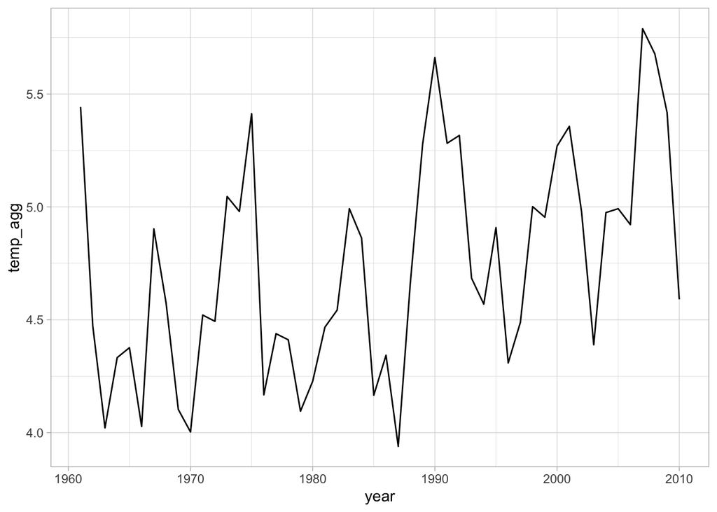

```r
temp_df %>%
  distinct(year, .keep_all = TRUE) %>%
  ggplot(aes(year, temp_agg)) +
  geom_line()
```

```r
write_csv(temp_df, paste0(home, "/baltic/FishMIP/Input-mizer/temp_df.csv"))
```